# Prevalence of Mental Illness Over Time: An Analysis

## Jiaqi Ma

### Introduction

Mental illness has always been a highly stigmatized and misconceived topic throughout history. From associating psychiatric conditions with demonology during the ancient years, to forcing patients diagnosed with mental disorders into poorly managed asylums during the 1800s (Corrigan, 1998), it is evident that people with mental illness are often mistreated and discriminated against in society. More importantly, the effects of being in a marginalized community are extremely damaging. For instance, people with mental illness are more likely to encounter barriers when accessing healthcare, in which many practitioners would treat them in an authoritarian way that dehumanizes the individual (Knaak et al., 2017). In addition, as a result of internalized stigma, people with mental illness tend to experience stronger decrease in self-esteem and self-efficacy, which would further worsen their overall mental health (Corrigan & Rao, 2012).

Given the negative impacts of stigmatization around mental illness, one way to deconstruct such mentality is to simply talk about mental health more and encourage people to participate in the discussion. Therefore, my goal with this project is to raise awareness around mental health by analyzing the prevalence of mental disorders in the U.S. over time.

### Data Collection and Curation

The first step of the analysis process is to obtain the appropriate data. After looking at a few sources, I came across the [Substance Abuse and Mental Health Data Archive (SAMHDA)](https://www.datafiles.samhsa.gov/), an official website of the Substance Abuse and Mental Health Services Administration by the U.S. government. Specifically, the dataset that I will be using is from the [1999-2020 National Survey on Drug Use and Health (NSDUH)](https://www.datafiles.samhsa.gov/dataset/national-survey-drug-use-and-health-2020-nsduh-2020-ds0001), which contains small area estimates on substance abuse and mental health outcomes in the United States. Since the dataset is available in SAS format, no data scraping was necessary. Instead, I simply downloaded and imported the data file. It is also important to note that I installed the pyreadstat package for faster performance on reading SAS data.

```python
#!pip install pyreadstat

import pyreadstat
import sqlite3
import pandas as pd
import numpy as np
import matplotlib.pyplot as plt
import seaborn as sns
from sklearn.linear_model import LinearRegression
from sklearn.model_selection import train_test_split
import warnings
warnings.filterwarnings('ignore')


# Import data and display
df, meta = pyreadstat.read_sas7bdat("nsduh.sas7bdat")
df.head()
```

|  | outname | pyearnm | area | outcome | stname | pyear | agegrp | est_total | low_total | up_total | ... | ncomp | wtintrr | pop | BSAE | low_sae | up_sae | ste_total | ste_sae | state | gen_corr |
| --- | --- | --- | --- | --- | --- | --- | --- | --- | --- | --- | --- | --- | --- | --- | --- | --- | --- | --- | --- | --- | --- |
| 0 | alcohol use in the past month | 1999-2000 | 0.0 | ALCMON | National | 1.0 | 0.0 | 102758.0 | 101497.0 | 104041.0 | ... | 138470.0 | 0.7127 | 222201087.0 | 0.462500 | 0.456780 | 0.468228 | NaN | NaN | -5.0 | NaN |
| 1 | alcohol use in the past month | 1999-2000 | 0.0 | ALCMON | National | 1.0 | 1.0 | 3819.0 | 3727.0 | 3911.0 | ... | 51140.0 | 0.8033 | 23285431.0 | 0.163999 | 0.160074 | 0.167980 | NaN | NaN | -5.0 | NaN |
| 2 | alcohol use in the past month | 1999-2000 | 0.0 | ALCMON | National | 1.0 | 2.0 | 16318.0 | 16152.0 | 16485.0 | ... | 45000.0 | 0.7430 | 28726150.0 | 0.568080 | 0.562280 | 0.573866 | NaN | NaN | -5.0 | NaN |
| 3 | alcohol use in the past month | 1999-2000 | 0.0 | ALCMON | National | 1.0 | 3.0 | 82621.0 | 81353.0 | 83887.0 | ... | 42330.0 | 0.6950 | 170189505.0 | 0.485456 | 0.478017 | 0.492901 | NaN | NaN | -5.0 | NaN |
| 4 | alcohol use in the past month | 1999-2000 | 0.0 | ALCMON | National | 1.0 | 4.0 | 98939.0 | 97664.0 | 100201.0 | ... | 87330.0 | 0.7020 | 198915655.0 | 0.497358 | 0.490982 | 0.503734 | NaN | NaN | -5.0 | NaN |

5 rows × 22 columns

As shown by the dataframe above, the original dataset contains 22 variables in total. Most of these variables will not be used. The only ones that I will be focusing on include:

- outcome: the name for the key substance use or mental health measures
- stname: the name of the census region or state
- agegrp: a numeric age group variable
- pyearnm: a pooled pair of survey years (except for 2020, which represents a single year)
- BSAE: the benchmarked small area estimates (i.e. prevalence rates)
- group: a map group with a range from 1 to 5 (Group 1 has the lowest estimates and Group 5 has the highest)

A more detailed documentation about these variables can be found [here](https://www.datafiles.samhsa.gov/sites/default/files/NSDUH_files/SAE/NSDUH-99-20-State-SAE-Documentation_2-10-22.docx).

Let's do some more data cleaning. Since this analysis is on mental illness, I will only keep the rows with outcome name AMIYR (any mental illness in the past year). Note that under these conditions, data is only available for 2008 and beyond. In terms of missing values, the group variable will show up as NaN for national-level and regional-level data, which is not a problem because I will not be operating group comparisons for those data. There are no missing values in other variables.

```python
df = df[["outcome", "pyearnm", "stname", "BSAE", "agegrp", "group"]]
df = df.loc[df["outcome"] == "AMIYR"]
df.reset_index(drop=True, inplace=True)
display(df)
```

|  | outcome | pyearnm | stname | BSAE | agegrp | group |
| --- | --- | --- | --- | --- | --- | --- |
| 0 | AMIYR | 2008-2009 | National | 0.182546 | 2.0 | NaN |
| 1 | AMIYR | 2008-2009 | National | 0.178637 | 3.0 | NaN |
| 2 | AMIYR | 2008-2009 | National | 0.179212 | 4.0 | NaN |
| 3 | AMIYR | 2008-2009 | Northeast | 0.186091 | 2.0 | NaN |
| 4 | AMIYR | 2008-2009 | Northeast | 0.181038 | 3.0 | NaN |
| ... | ... | ... | ... | ... | ... | ... |
| 2179 | AMIYR | 2019-2020 | Wisconsin | 0.201294 | 3.0 | 3.0 |
| 2180 | AMIYR | 2019-2020 | Wisconsin | 0.218299 | 4.0 | 3.0 |
| 2181 | AMIYR | 2019-2020 | Wyoming | 0.372206 | 2.0 | 5.0 |
| 2182 | AMIYR | 2019-2020 | Wyoming | 0.215625 | 3.0 | 4.0 |
| 2183 | AMIYR | 2019-2020 | Wyoming | 0.236322 | 4.0 | 4.0 |

2184 rows × 6 columns

In addition, the documentation mentioned that there are two different datasets for 2010-2011: published estimates and updated estimates, as shown here:

```python
display(df[df["pyearnm"].str.contains("2010-2011")])
```

|  | outcome | pyearnm | stname | BSAE | agegrp | group |
| --- | --- | --- | --- | --- | --- | --- |
| 336 | AMIYR | 2010-2011 (published) | National | 0.183303 | 2.0 | NaN |
| 337 | AMIYR | 2010-2011 (published) | National | 0.178289 | 3.0 | NaN |
| 338 | AMIYR | 2010-2011 (published) | National | 0.179029 | 4.0 | NaN |
| 339 | AMIYR | 2010-2011 (published) | Northeast | 0.183694 | 2.0 | NaN |
| 340 | AMIYR | 2010-2011 (published) | Northeast | 0.176461 | 3.0 | NaN |
| ... | ... | ... | ... | ... | ... | ... |
| 667 | AMIYR | 2010-2011 (updated) | Wisconsin | 0.174226 | 3.0 | 2.0 |
| 668 | AMIYR | 2010-2011 (updated) | Wisconsin | 0.175348 | 4.0 | 2.0 |
| 669 | AMIYR | 2010-2011 (updated) | Wyoming | 0.202419 | 2.0 | 4.0 |
| 670 | AMIYR | 2010-2011 (updated) | Wyoming | 0.175990 | 3.0 | 2.0 |
| 671 | AMIYR | 2010-2011 (updated) | Wyoming | 0.179910 | 4.0 | 3.0 |

336 rows × 6 columns

For accuracy purposes, I will keep the updated estimates and drop the other rows. I will also rename them to match the year format.

```python
df = df[~df.pyearnm.str.contains("published", na=False)]
df.pyearnm = df.pyearnm.apply(lambda x: "2010-2011" if "updated" in x else x)
display(df[df["pyearnm"].str.contains("2010-2011")])
```

|  | outcome | pyearnm | stname | BSAE | agegrp | group |
| --- | --- | --- | --- | --- | --- | --- |
| 504 | AMIYR | 2010-2011 | National | 0.183303 | 2.0 | NaN |
| 505 | AMIYR | 2010-2011 | National | 0.178289 | 3.0 | NaN |
| 506 | AMIYR | 2010-2011 | National | 0.179029 | 4.0 | NaN |
| 507 | AMIYR | 2010-2011 | Northeast | 0.183694 | 2.0 | NaN |
| 508 | AMIYR | 2010-2011 | Northeast | 0.176461 | 3.0 | NaN |
| ... | ... | ... | ... | ... | ... | ... |
| 667 | AMIYR | 2010-2011 | Wisconsin | 0.174226 | 3.0 | 2.0 |
| 668 | AMIYR | 2010-2011 | Wisconsin | 0.175348 | 4.0 | 2.0 |
| 669 | AMIYR | 2010-2011 | Wyoming | 0.202419 | 2.0 | 4.0 |
| 670 | AMIYR | 2010-2011 | Wyoming | 0.175990 | 3.0 | 2.0 |
| 671 | AMIYR | 2010-2011 | Wyoming | 0.179910 | 4.0 | 3.0 |

168 rows × 6 columns

### Data Visualization

#### National-Level

I want to start off by analyzing data on the national-level. There are three observations every survey year, with each observation representing a different age group, but I will disregard this variable for now and focus on the overall trend. Using these data points, I would like to create a scatterplot demonstrating the prevalence of mental illness from survey year 2008-2009 to 2019-2020.

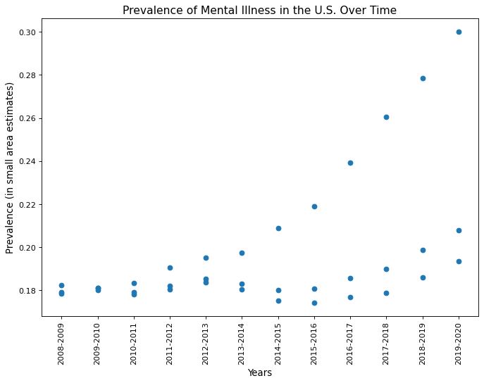

```python
# New dataframe for national-level data
national_df = df.loc[df["stname"] == "National"]

# Create scatterplot
fig, ax = plt.subplots(figsize=(10,7), dpi=80)
ax.scatter(x = national_df["pyearnm"], y = national_df["BSAE"])
plt.xticks(rotation = 90)
plt.title("Prevalence of Mental Illness in the U.S. Over Time", fontsize=14)
plt.xlabel("Years", fontsize=12)
plt.ylabel("Prevalence (in small area estimates)", fontsize=12)
plt.show()
```

When observing the plot, it is evident that the overall prevalence of individuals diagnosed with mental disorders in the U.S. increased significantly from 2008 to 2020. Although there seems to be outstanding values for some survey years (due to differences in age group, which will be discussed later), I believe there still exists a positive correlation between time and prevalence in mental illness. To verify whether this relationship actually exists, I will add a regression line to the plot using Seaborn. However, since regression calculation requires both x and y variables to be numerical values, I will temporarily change the values in pyearnm into integers by cutting off the latter year. For example, "2008-2009" (type str) would become 2008 (type int).

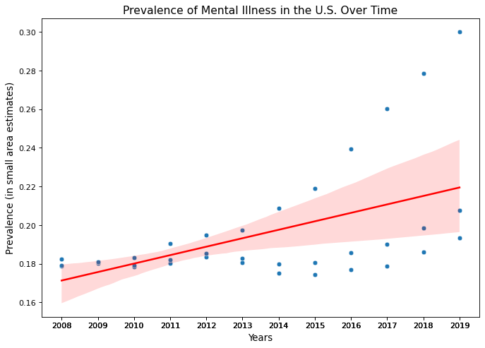

```python
# Create new column in national_df to store converted values of pyearnm
intyear = []
for index, row in national_df.iterrows():
    temp = row["pyearnm"]
    intyear.append(int(temp[:4]))

national_df["newYear"] = intyear


# Create plot with regression line
fig, ax = plt.subplots(figsize=(10,7), dpi=80)
ax = sns.scatterplot(data=national_df, x="newYear", y="BSAE")
sns.regplot(data=national_df, x="newYear", y="BSAE", scatter=False, ax=ax, line_kws={'color': 'red'})
plt.xticks(national_df["newYear"])
plt.title("Prevalence of Mental Illness in the U.S. Over Time", fontsize=14)
plt.xlabel("Years", fontsize=12)
plt.ylabel("Prevalence (in small area estimates)", fontsize=12)
plt.show()
```

As expected, the regression line is increasing at a steady rate across the plot, hence further demonstrating the positive relationship between prevalence of mental illness and years. But at the same time, there are other important factors that must be taken into consideration when evaluating this relationship. Since the data was collected based on the number of individuals diagnosed with mental disorders, it is possible that the number is increasing because psychological diagnosis has become more accessible throughout the years. Nevertheless, this correlation still makes sense due to alarming trends such as increased financial pressure, increased adoption of electronic media, and reduced sleep.

Moreover, a study done by Twenge et al. (2019) discovered that young adults are particularly at risk for developing mood disorders and suicidal thoughts. They suspect that recent cultural trends tend to have greater influence on young adults, resulting in a cohort effect of psychological distress. With these findings in mind, I am curious to see whether the NSDUH dataset would replicate the same results. In order to accomplish this, I could use the agegrp variable from the dataset, in which its values are as follows:

- 0: people aged 12 or older
- 1: youths aged 12 to 17
- 2: young adults aged 18 to 25
- 3: adults aged 26 or older
- 4: adults aged 18 or older

Note that the national-level data only contains age groups of 2, 3, and 4. According to the study, observations for age group 2 (young adults) should have the highest prevalence of mental illness, aka the highest BSAE value. Therefore, I will calculate the average of all observation values for every age group and compare them by using a bar plot.

| agegrp | BSAE |
| --- | --- |
| 2.0 | 0.219593 |
| 3.0 | 0.180611 |
| 4.0 | 0.186015 |

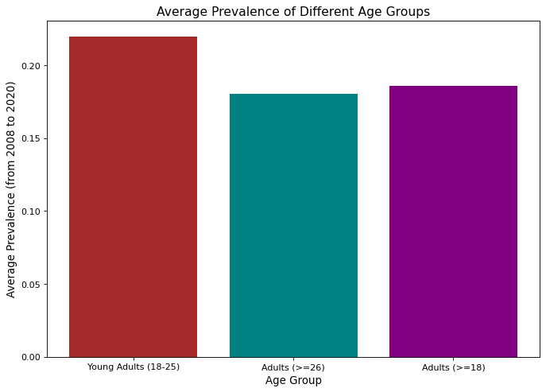

```python
# Create a new dataframe with BSAE and agegrp
# Group by the agegrp column and calculate the mean of the BSAE column
avg_national = national_df[["BSAE", "agegrp"]]
avg_national = avg_national.groupby("agegrp").mean()
display(avg_national)

# Create a bar plot displaying the three means
ageGroup = ["Young Adults (18-25)", "Adults (>=26)", "Adults (>=18)"]
fig = plt.figure(figsize=(10,7), dpi=80)
plt.bar(ageGroup, avg_national["BSAE"], color=["brown", "teal", "purple"])
plt.title("Average Prevalence of Different Age Groups", fontsize=14)
plt.xlabel("Age Group", fontsize=12)
plt.ylabel("Average Prevalence (from 2008 to 2020)", fontsize=12)
plt.show()
```

Looking at the mean prevalence and the bar plot, young adults (aged from 18-25) have the highest average prevalence rate compared to the other groups, and thus reinforcing the findings mentioned above. Additionally, this emphasizes the need for the younger generations to become more aware of their mental health and develop resistance against overwhelming influences from their environment. Twenge et al. (2019) also suggested that making sure digital media use does not interfere with our sleep is one of the most important components of maintaining good mental health.

#### State-Level

Now that I have a better understanding of the data on a national-level, I would like to make more comparisons by examining the prevalence of mental illness in different states. Specifically, I want to utilize the group variable from the original dataset, which ranks each state based on its prevalence rate. Group 1 represents the lowest estimates/prevalence, while Group 5 represents the highest.

To start off, I am curious to see the overall distribution of group rankings among all states because it will help me better assess the severity of mental health problems in the country. In this case, I am only looking at the proportion, and there is no need to show changes over time, so I decided to use a pie chart after grouping all observations by their group value and obtaining the size of each group. Note that only state-level observations have a valid group value.

```
group
1.0    360
2.0    361
3.0    397
4.0    360
5.0    358
dtype: int64
```

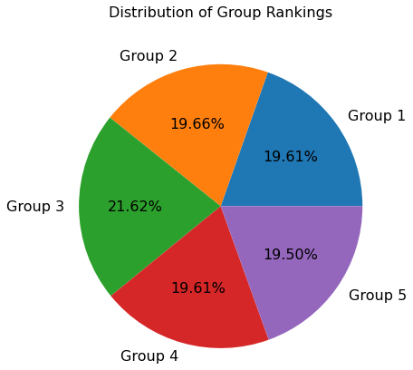

```python
# Group observations by their group value and obtain the size for all five groups
pie_df = df.groupby(["group"]).size()
print(pie_df)
print("")

# Create a pie chart to show the proportion
pie_labels = ["Group 1", "Group 2", "Group 3", "Group 4", "Group 5"]
ax = pie_df.plot(kind="pie",  labels=pie_labels, autopct="%0.2f%%", radius=1.8, textprops={"fontsize": 16}, ylabel="")
plt.title("Distribution of Group Rankings", pad=100, fontsize=16)
plt.show()
```

Although I was hoping to see greater differences in proportion, it turns out that all five groups are close in size. Slightly more observations are under Group 3 (about 2% more), but I believe the difference is too small for me to claim it as significant.

Therefore, to better compare the mental illness prevalence between states, I will specifically examine the top ten observations under Group 5 and Group 1. I can accomplish this by grouping all observations under Group 5 by the state name and count the frequency of each state being ranked as Group 5. Then I will repeat the same process for observations under Group 1.

|  | State | NumHigh |
| --- | --- | --- |
| 0 | Utah | 34 |
| 1 | Oregon | 32 |
| 2 | Washington | 27 |
| 3 | Idaho | 27 |
| 4 | West Virginia | 25 |
| 5 | Indiana | 17 |
| 6 | Oklahoma | 15 |
| 7 | Rhode Island | 15 |
| 8 | Maine | 13 |
| 9 | Ohio | 12 |

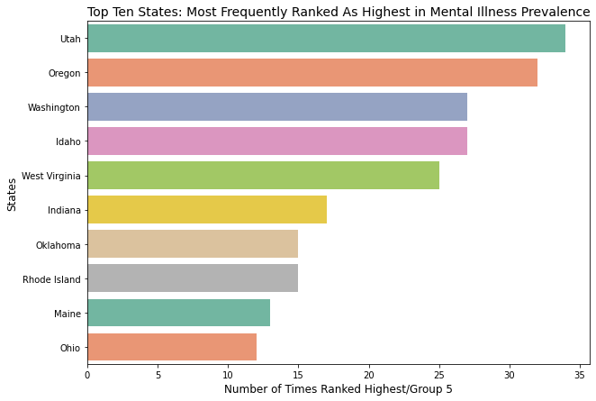

```python
# Creat new df for states that are ranked as Group 5
high_states = df.loc[df["group"] == 5]

# Group by states and count how many times each state is ranked the highest
count = high_states.groupby(["stname"]).size()

# Update high_state and sort based on the number of times they were ranked as the highest
high_states = pd.DataFrame({"State": count.index, "NumHigh": count.values})
high_states = high_states.sort_values(by=["NumHigh"], ascending=False)
high_states.reset_index(drop=True, inplace=True)

# Display top 10
topTenHigh = high_states.head(10)
display(topTenHigh)

# Create bar graph
plt.figure(figsize=(10,7))
sns.barplot(y=topTenHigh["State"], x=topTenHigh["NumHigh"], orient="h", palette="Set2")
plt.title("Top Ten States: Most Frequently Ranked As Highest in Mental Illness Prevalence", fontsize=14)
plt.xlabel("Number of Times Ranked Highest/Group 5", fontsize=12)
plt.ylabel("States", fontsize=12)
plt.show()
```

|  | State | NumLow |
| --- | --- | --- |
| 0 | Texas | 34 |
| 1 | Florida | 33 |
| 2 | New Jersey | 26 |
| 3 | Illinois | 24 |
| 4 | Maryland | 20 |
| 5 | Georgia | 19 |
| 6 | North Dakota | 18 |
| 7 | South Dakota | 16 |
| 8 | Connecticut | 15 |
| 9 | Hawaii | 14 |

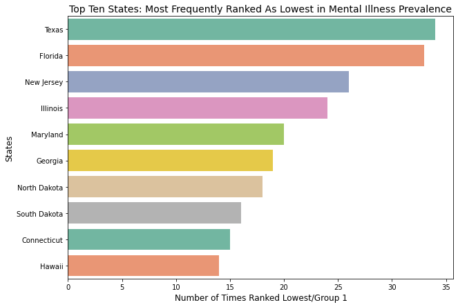

```python
# Creat new df for states that are ranked as Group 1
low_states = df.loc[df["group"] == 1]

# Group by states and count how many times each state is ranked the lowest
count = low_states.groupby(["stname"]).size()

# Update low_state and sort based on the number of times they were ranked as the lowest
low_states = pd.DataFrame({"State": count.index, "NumLow": count.values})
low_states = low_states.sort_values(by=["NumLow"], ascending=False)
low_states.reset_index(drop=True, inplace=True)

# Display top 10
topTenLow = low_states.head(10)
display(topTenLow)

# Create bar graph
plt.figure(figsize=(10,7))
sns.barplot(y=topTenLow["State"], x=topTenLow["NumLow"], orient="h", palette="Set2")
plt.title("Top Ten States: Most Frequently Ranked As Lowest in Mental Illness Prevalence", fontsize=14)
plt.xlabel("Number of Times Ranked Lowest/Group 1", fontsize=12)
plt.ylabel("States", fontsize=12)
plt.show()
```

The two bar graphs above provide a clear visualization of how states differ in terms of mental illness prevalence rate. Taking a closer look into each plot, Utah has the highest number of Group 5 observations, totaling to 34 times. This information is extremely useful because it allows researchers to recognize which states are at higher risk for mental illness development and encourage them to come up with solutions accordingly. On the other hand, Texas has the highest number of Group 1 observations, also totaling to 34 times. Since these states (in the second plot) are constantly shown to have low prevalence rate, researchers can gain insight into mental health improvement/prevention by observing the environment and social interactions in these states.

### Hypothesis Testing

As hinted in previous discussions, one potential factor for the increasing prevalence in mental disorders is due to the heightened reliance on digital devices and social media. As much as technology advancement has brought tremendous benefits to our society, the negative effects that come along the way could be detrimental as well. Supported by the work of Wacks and Weinstein (2021), it was found that excessive smartphone use is associated with difficulties in cognitive-emotion regulation, impaired cognitive function, addiction to social networking, and low self-esteem. As a result, those individuals are more susceptible to developing depression, anxiety, OCD, and alcohol use disorder.

Given that many research studies have reinforced the same findings, I want to verify the relationship between smartphone use and mental illness prevalence by creating a predictive model. Since I believe there exists a positive linear relationship between smartphone use and mental disorders prevalence, it would be appropriate for me to use linear regression here.

In addition, before I can begin the regression analysis, I obtained a dataset regarding [daily hours spent with digital media in the U.S. from 2008 to 2018](https://ourworldindata.org/grapher/daily-hours-spent-with-digital-media-per-adult-user?country=~USA). The dataset is available in CSV format so data scraping was not needed.

```python
# Import dataset for daily hours spent with digital media in the U.S. from 2008 to 2018
hr_df = pd.read_csv("digitalTimeSpent.csv")

# Tidy data
mobile_df = hr_df[["Year", "Mobile (BOND Internet Trends (2019))"]]
mobile_df = mobile_df.rename(columns={"Year": "year", "Mobile (BOND Internet Trends (2019))": "mobileHr"})
display(mobile_df)
```

|  | year | mobileHr |
| --- | --- | --- |
| 0 | 2008 | 0.3 |
| 1 | 2009 | 0.3 |
| 2 | 2010 | 0.4 |
| 3 | 2011 | 0.8 |
| 4 | 2012 | 1.6 |
| 5 | 2013 | 2.3 |
| 6 | 2014 | 2.6 |
| 7 | 2015 | 2.8 |
| 8 | 2016 | 3.1 |
| 9 | 2017 | 3.3 |
| 10 | 2018 | 3.6 |

```
Coefficient of determination:  0.885808063277595
```

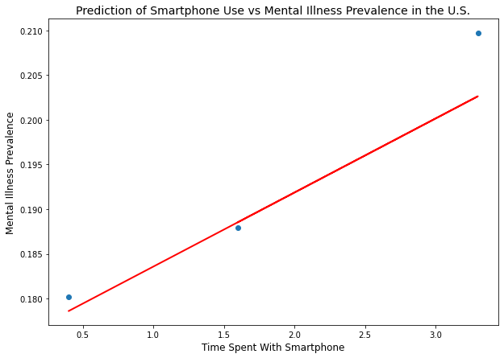

```python
# Only consider observations from 2008 to 2018
# Obtain average prevalence rate for each year to match with mobile_df length
temp = national_df.loc[(national_df["newYear"] >= 2008) & (national_df["newYear"] <= 2018)]
new_national = temp.groupby("newYear").mean()

# Implement linear regression model for prediction
X = mobile_df["mobileHr"].values.reshape(-1,1)
y = new_national["BSAE"].values.reshape(-1,1)

X_train, X_test, y_train, y_test = train_test_split(X, y, test_size = 0.25, random_state =0)

regressor = LinearRegression()
regressor.fit(X_train,y_train)
y_pred = regressor.predict(X_test)
print("Coefficient of determination: ", regressor.score(X_test, y_test))
print("")

plt.figure(figsize=(10,7))
plt.scatter(X_test, y_test)
plt.plot(X_test, y_pred, color='red', linewidth=2)
plt.title("Prediction of Smartphone Use vs Mental Illness Prevalence in the U.S.", fontsize=14)
plt.xlabel("Time Spent With Smartphone", fontsize=12)
plt.ylabel("Mental Illness Prevalence", fontsize=12)
plt.show()
```

With time spent on smartphone being the independent variable and mental illness prevalence being the dependent variable, the linear regression analysis resulted in a high coefficient of determination (0.886), indicating that the regression model is a good fit for the data. Hence, the hypothesis of smartphone use being positively correlated with mental health prevalence is also correct. However, one down side about this regression analysis is that the datasets are really small, which may affect the accuracy of the model.

### Conclusion

After performing a series of data analysis, it is indisputable that mental illness is an extremely critical problem in the U.S. and the prevalence rate will continue to rise in future years. Moreover, with support from several research studies, teenagers and young adults tend to be more susceptible to developing psychiatric conditions. While stigmatization around mental illness is still relatively strong in society, it is important for every one of us to start taking actions and learning how to properly assist those in need.

We can combat stigma with education by providing contradictory information. It has been shown that brief educational courses on mental illness are able to successfully diminish stigmatizing attitudes among a wide range of audience (Rüsch et al., 2005). In addition, promoting films that have an accurate and sympathetic portrayal of mental illness is an essential measure to abolish stigmatization as well (Gaebel & Baumann, 2003). Some examples of movies with a positive representation of mental disorders include "A Beautiful Mind", "Rain Man", and "What About Bob."

Mental health and intersectional resources:

- [American Association on Intellectual and Developmental Disabilities](http://www.aamr.org/)
- [Asian American Psychological Association](https://aapaonline.org/)
- [Black Mental Health Alliance](https://blackmentalhealth.com/)
- [Crisis Textline](https://www.crisistextline.org/)
- [Mental Health America](https://www.mhanational.org/)
- [National Alliance on Mental Illness](https://www.nami.org/home)
- [National Latino Behavioral Health Association](http://www.nlbha.org/)
- [SAMHSA's National Helpline](https://www.samhsa.gov/find-help/national-helpline)
- [The Trevor Project](https://www.thetrevorproject.org/)
- [We R Native](https://www.wernative.org/)

### References

Corrigan, P. W. (1998). The impact of stigma on severe mental illness. *Cognitive and Behavioral Practice, 5*(2), 201–222. https://doi.org/10.1016/S1077-7229(98)80006-0

Corrigan, P. W., & Rao, D. (2012). On the self-stigma of mental illness: Stages, disclosure, and strategies for change. *Canadian journal of psychiatry. Revue canadienne de psychiatrie, 57*(8), 464–469. https://doi.org/10.1177/070674371205700804

Gaebel, W., & Baumann, A. E. (2003). Interventions to reduce the stigma associated with severe mental illness: Experiences from the open the doors program in Germany. *Canadian journal of psychiatry. Revue canadienne de psychiatrie, 48*(10), 657–662. https://doi.org/10.1177/070674370304801003

Knaak, S., Mantler, E., & Szeto, A. (2017). Mental illness-related stigma in healthcare: Barriers to access and care and evidence-based solutions. *Healthcare management forum, 30*(2), 111-116. https://doi.org/10.1177/0840470416679413

Rüsch, N., Angermeyer, M., & Corrigan, P. (2005). Mental illness stigma: Concepts, consequences, and initiatives to reduce stigma. *European Psychiatry, 20*(8), 529-539. https://doi.org/10.1016/j.eurpsy.2005.04.004

Twenge, J. M., Cooper, A. B., Joiner, T. E., Duffy, M. E., & Binau, S. G. (2019). Age, period, and cohort trends in mood disorder indicators and suicide-related outcomes in a nationally representative dataset, 2005-2017. *Journal of abnormal psychology, 128*(3), 185–199. https://doi.org/10.1037/abn0000410

Wacks, Y., & Weinstein, A. M. (2021). Excessive smartphone use is associated with health problems in adolescents and young adults. *Frontiers in psychiatry, 12*, 669042. https://doi.org/10.3389/fpsyt.2021.669042